# Assignment 6

In this assignment, you'll analyze a collection of data sets from the [San Francisco Open Data Portal](http://data.sfgov.org/) and [Zillow](https://www.zillow.com/). The data sets have been stored in the SQLite database `sf_data.sqlite`, which you can [download here](http://anson.ucdavis.edu/~nulle/sf_data.sqlite). The database contains the following tables:

| Table | Description |
| --- | --- |
| `crime` | Crime reports dating back to 2010. |
| `mobile_food_locations` | List of all locations where mobile food vendors sell. |
| `mobile_food_permits` | List of all mobile food vendor permits. More details [here](https://data.sfgov.org/api/views/rqzj-sfat/files/8g2f5RV4PEk0_b24iJEtgEet9gnh_eA27GlqoOjjK4k?download=true&filename=DPW_DataDictionary_Mobil… |
| `mobile_food_schedule` | Schedules for mobile food vendors. |
| `noise` | Noise complaints dating back to August 2015. |
| `parking` | List of all parking lots. |
| `parks` | List of all parks. |
| `schools` | List of all schools. |
| `zillow` | Zillow rent and housing statistics dating back to 1996. More details [here](https://www.zillow.com/research/data/). |

The `mobile_food_` tables are explicitly connected through the `locationid` and `permit` columns. The other tables are not connected, but you may be able to connect them using dates, latitude/longitude, or postal codes.

Shapefiles for US postal codes are available [here](https://www.census.gov/geo/maps-data/data/cbf/cbf_zcta.html). These may be useful for converting latitude/longitude to postal codes.

Shapefiles for San Francisco Neighborhoods are available [here](https://data.sfgov.org/Geographic-Locations-and-Boundaries/SF-Find-Neighborhoods/pty2-tcw4).

**Exercise 1.1.** Which mobile food vendor(s) sells at the most locations?

```python
%reset
```

```
Once deleted, variables cannot be recovered. Proceed (y/[n])? Y
```

```python
import sqlite3 as sql
import pandas as pd
import numpy as np
```

```python
db = sql.connect("sf_data.sqlite")
```

```python
pd.read_sql("SELECT * FROM sqlite_master", db)
```

|  | type | name | tbl_name | rootpage | sql |
| --- | --- | --- | --- | --- | --- |
| 0 | table | crime | crime | 2 | CREATE TABLE "crime" (\n"IncidntNum" INTEGER,\... |
| 1 | table | noise | noise | 35775 | CREATE TABLE "noise" (\n"CaseID" INTEGER,\n "... |
| 2 | table | parking | parking | 35921 | CREATE TABLE "parking" (\n"Owner" TEXT,\n "Ad... |
| 3 | table | schools | schools | 35944 | CREATE TABLE "schools" (\n"Name" TEXT,\n "Ent... |
| 4 | table | parks | parks | 35961 | CREATE TABLE "parks" (\n"Name" TEXT,\n "Type"... |
| 5 | table | zillow | zillow | 35967 | CREATE TABLE "zillow" (\n"RegionName" INTEGER,... |
| 6 | table | mobile_food_permits | mobile_food_permits | 36050 | CREATE TABLE "mobile_food_permits" (\n"permit"... |
| 7 | table | mobile_food_locations | mobile_food_locations | 36060 | CREATE TABLE "mobile_food_locations" (\n"locat... |
| 8 | table | mobile_food_schedule | mobile_food_schedule | 36079 | CREATE TABLE "mobile_food_schedule" (\n"locati... |

By look through the three mobile food tables, one applicant only has one permit. Therefore, one method is that we can just look at mobile food schedule table, and find out which permit corresponding to the most locationid. Then, we use that permit number to find out which mobile food vendor sells at the most locations.

The second method is combine all the three three mobile*food* tables, and directly find out which mobile food vendor sells at the most location.

# Method 1

Since one applicant only has one permit, we can just look at mobile_food_schedule table, and find out which permit corresponding to the most locationid. Then, we use that permit number to find out which mobile food vendor sells at the most locations.

```python
unique = pd.read_sql("SELECT DISTINCT locationid, permit FROM mobile_food_schedule",db)
```

```python
group_df = unique.groupby('permit').size()
group_df.head()
```

```
permit
11MFF-0040    2
11MFF-0070    1
11MFF-0175    1
11MFF-0177    2
12MFF-0083    1
dtype: int64
```

```python
group_df.sort_values(axis = 0, ascending = False).head()
```

```
permit
17MFF-0110    58
13MFF-0102    37
17MFF-0111    37
17MFF-0090    33
16MFF-0051    23
dtype: int64
```

```python
# From the above, we see that the applicant whose permit number is "17MFF-0110" sells at the most locations
# So I want to find the applicant in the mobile_food_permit table
pd.read_sql("SELECT * FROM mobile_food_permits WHERE permit= '17MFF-0110'", db)
```

|  | permit | Status | Applicant | FacilityType | FoodItems | PriorPermit | Approved | Expiration |
| --- | --- | --- | --- | --- | --- | --- | --- | --- |
| 0 | 17MFF-0110 | REQUESTED | May Catering | Truck | Cold Truck: Sandwiches: fruit: snacks: candy: ... | 1 | None | 2018-05-06 12:00:00 |

Therefore, the mobile food vender whose name is May Catering sells at the most location.

# Method 2

Different method to find the mobile food vendor by combining all the three mobile food tables.

```python
# combine unique mobile_food_schedule table and mobile_food_locations join by locationid
db.execute(
    "CREATE TABLE mobile_df AS SELECT DISTINCT L.*, R.* "
    "FROM (SELECT DISTINCT locationid, permit FROM mobile_food_schedule) AS L INNER JOIN mobile_food_locations AS R ON L.locationid = R.locationid"
)
```

```
<sqlite3.Cursor at 0x12a1f6e30>
```

```python
pd.read_sql("SELECT * FROM mobile_df LIMIT 5", db)
```

|  | locationid | permit | locationid:1 | LocationDescription | Address | Latitude | Longitude |
| --- | --- | --- | --- | --- | --- | --- | --- |
| 0 | 762182 | 16MFF-0027 | 762182 | TOWNSEND ST: 05TH ST to 06TH ST (400 - 499) | 444 TOWNSEND ST | 37.774871 | -122.398532 |
| 1 | 437211 | 13MFF-0102 | 437211 | MISSOURI ST: 20TH ST to SIERRA ST (500 - 630) | 555 MISSOURI ST | 37.759304 | -122.395902 |
| 2 | 765880 | 16MFF-0069 | 765880 | 17TH ST: SAN BRUNO AVE to UTAH ST (2200 - 2299) | 2222 17TH ST | 37.765216 | -122.406007 |
| 3 | 765690 | 16MFF-0051 | 765690 | CESAR CHAVEZ ST: EVANS AVE to KANSAS ST (2100 ... | 2323 CESAR CHAVEZ ST | 37.748801 | -122.400552 |
| 4 | 761933 | 16MFF-0024 | 761933 | 05TH ST: BLUXOME ST to TOWNSEND ST (650 - 699) | 670 05TH ST | 37.775589 | -122.397977 |

```python
# Then combine with mobile_food_permits table join on permit
db.execute(
    "CREATE TABLE mobile_final AS SELECT L.*, R.Status, R.Applicant "
    "FROM mobile_df AS L LEFT JOIN mobile_food_permits AS R ON L.permit = R.permit"
)
```

```
<sqlite3.Cursor at 0x125b3e880>
```

```python
pd.read_sql("SELECT * FROM mobile_final LIMIT 5", db)
```

|  | locationid | permit | locationid:1 | LocationDescription | Address | Latitude | Longitude | Status | Applicant |
| --- | --- | --- | --- | --- | --- | --- | --- | --- | --- |
| 0 | 762182 | 16MFF-0027 | 762182 | TOWNSEND ST: 05TH ST to 06TH ST (400 - 499) | 444 TOWNSEND ST | 37.774871 | -122.398532 | APPROVED | F & C Catering |
| 1 | 437211 | 13MFF-0102 | 437211 | MISSOURI ST: 20TH ST to SIERRA ST (500 - 630) | 555 MISSOURI ST | 37.759304 | -122.395902 | EXPIRED | Natan's Catering |
| 2 | 765880 | 16MFF-0069 | 765880 | 17TH ST: SAN BRUNO AVE to UTAH ST (2200 - 2299) | 2222 17TH ST | 37.765216 | -122.406007 | APPROVED | Munch A Bunch |
| 3 | 765690 | 16MFF-0051 | 765690 | CESAR CHAVEZ ST: EVANS AVE to KANSAS ST (2100 ... | 2323 CESAR CHAVEZ ST | 37.748801 | -122.400552 | APPROVED | Park's Catering |
| 4 | 761933 | 16MFF-0024 | 761933 | 05TH ST: BLUXOME ST to TOWNSEND ST (650 - 699) | 670 05TH ST | 37.775589 | -122.397977 | APPROVED | Off the Grid Services, LLC |

```python
df = pd.read_sql("SELECT Applicant, COUNT(*) AS count FROM mobile_final GROUP BY Applicant",db)
```

```python
df.sort_values('count',axis = 0, ascending = False).head()
```

|  | Applicant | count |
| --- | --- | --- |
| 68 | May Catering | 58 |
| 3 | Anas Goodies Catering | 37 |
| 77 | Natan's Catering | 37 |
| 59 | Liang Bai Ping | 33 |
| 80 | Park's Catering | 23 |

According to the table above, I get the same result as in the method 1. The mobile food vender whose name is May Catering sells at the most location

```python
db.execute("DROP TABLE mobile_df")
```

```
<sqlite3.Cursor at 0x12d7efe30>
```

**Exercise 1.2.** Ask and use the database to analyze 5 questions about San Francisco. For each question, write at least 150 words and support your answer with plots. Make a map for at least 2 of the 5 questions.

You should try to come up with some questions on your own, but these are examples of reasonable questions:

- Which parts of the city are the most and least expensive?
- Which parts of the city are the most dangerous (and at what times)?
- Are noise complaints and mobile food vendors related?
- What are the best times and places to find food trucks?
- Is there a relationship between housing prices and any of the other tables?

Please make sure to clearly state each of your questions in your submission.

```python
# Make Jupyter to automatically display matplotlib plots.
%matplotlib inline

from mpl_toolkits.basemap import Basemap
import shapely.geometry as geom
import geopandas as gpd

import matplotlib.pyplot as plt
# Make plots larger.
plt.rcParams['figure.figsize'] = (10, 10)
from matplotlib.patches import Polygon
from matplotlib.collections import PatchCollection
from matplotlib.colors import Normalize
import collections
from itertools import chain
import seaborn as sns
from matplotlib import cm
```

# Problem 1:

Which parts of the city are the most and least expensive?

```python
# Make a dataframe to get the mean of the sold price of houses for every RegionName
zillow = pd.read_sql("SELECT * FROM zillow", db)
a = zillow.groupby(['RegionName'])['MedianSoldPricePerSqft_AllHomes'].mean()
house_price = pd.DataFrame(list(a.index))
price = a.values
house_price['price'] = pd.Series(price,index = house_price.index)
house_price = house_price.rename(columns = {0:'RegionName'})
```

```python
from pyzipcode import ZipCodeDatabase
import zipcode
```

```python
# use zipcode to get the longtitude and latitude for every RegionName
zipCodeList = house_price.RegionName
Zip_Lon = {i:zipcode.isequal(str(i)).to_dict()['lon'] for i in zipCodeList}
Zip_La = {i: zipcode.isequal(str(i)).to_dict()['lat'] for i in zipCodeList}
Zip_Lon[94108] = -122.41
Zip_La[94108] = 37.792
```

```python
house_price['Lat'] = house_price['RegionName'].map(Zip_La)
house_price['Lon'] = house_price['RegionName'].map(Zip_Lon)
house_price = house_price.sort_values('price',axis = 0, ascending = False)
house_price = house_price.reset_index(drop=True)
house_price
```

|  | RegionName | price | Lat | Lon |
| --- | --- | --- | --- | --- |
| 0 | 94104 | 1336.128581 | 37.790 | -122.40 |
| 1 | 94105 | 798.257824 | 37.780 | -122.39 |
| 2 | 94123 | 696.166788 | 37.800 | -122.43 |
| 3 | 94158 | 657.211820 | 37.760 | -122.39 |
| 4 | 94114 | 650.127729 | 37.750 | -122.43 |
| 5 | 94133 | 638.636839 | 37.800 | -122.41 |
| 6 | 94102 | 626.417276 | 37.770 | -122.41 |
| 7 | 94109 | 618.325709 | 37.790 | -122.42 |
| 8 | 94115 | 611.771452 | 37.780 | -122.43 |
| 9 | 94103 | 604.009929 | 37.770 | -122.41 |
| 10 | 94107 | 592.651062 | 37.760 | -122.39 |
| 11 | 94117 | 580.217632 | 37.760 | -122.44 |
| 12 | 94131 | 560.122866 | 37.740 | -122.44 |
| 13 | 94118 | 558.667047 | 37.780 | -122.46 |
| 14 | 94110 | 543.998864 | 37.740 | -122.41 |
| 15 | 94108 | 501.013201 | 37.792 | -122.41 |
| 16 | 94127 | 490.745386 | 37.730 | -122.45 |
| 17 | 94121 | 467.890585 | 37.770 | -122.49 |
| 18 | 94116 | 466.570200 | 37.740 | -122.48 |
| 19 | 94122 | 453.210167 | 37.760 | -122.48 |
| 20 | 94111 | 445.680441 | 37.790 | -122.39 |
| 21 | 94112 | 416.744886 | 37.720 | -122.44 |
| 22 | 94132 | 385.384982 | 37.720 | -122.48 |
| 23 | 94080 | 375.629802 | 37.650 | -122.42 |
| 24 | 94134 | 347.027455 | 37.720 | -122.41 |
| 25 | 94124 | 297.008046 | 37.730 | -122.38 |

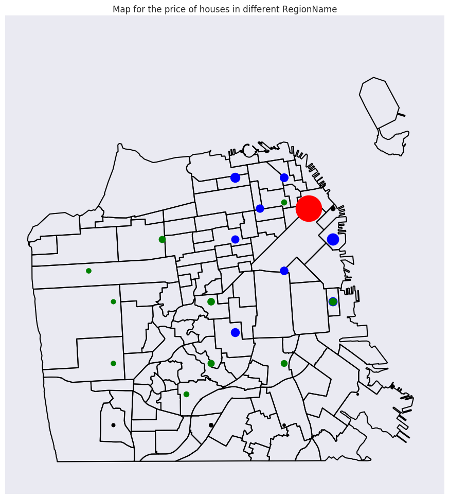

```python
my_map = Basemap(llcrnrlon=-122.524120, llcrnrlat=37.697668, urcrnrlon= -122.344332, urcrnrlat=37.852423,
                 resolution="f", projection="merc"
)

plt.rcParams['figure.figsize'] = (12, 12)
my_map.readshapefile("SF Find Neighborhoods/geo_export_c3dd82f5-c220-4242-9541-7c95ca203a9f",
                     "areas", zorder=2, linewidth=1.5)
for lon, lat, price in zip(house_price.Lon, house_price.Lat, house_price.price):
    x, y = my_map(lon, lat)
    color = 'r'
    if price <= 1000:
        color = "b"
    if price <= 600:
        color = "g"
    if price <= 450:
        color = "k"
    my_map.plot(x, y, color + "o", markersize = (price/120)**1.5)

plt.title('Map for the price of houses in different RegionName')
my_map
```

For this question, I am trying to figure out which part of the San Francisco are the most and least expensive. In the Zillow table, there are many variables. I choose Median Sold Price Per Sqft as the price variables, and group price label by zip code. If we look at the price variables, we can see that there is a region 94104 has the most expensive houses in SF. Its price is over 1000 dollars per square. I mark this dot as red biggest dot in the map. I also mark the dots to be blue if the houses’ prices are between 1000 and 600, mark the dots to be green if the houses’ price are between 450 and 600, and mark dots to be black if houses’ price less than 450. Since in the Zillow table, we only have its zip code. In order to draw base map, we need longitude and latitude, so I use package ‘zipcode’ to get longitude and latitude of every region.

If we look at the map, we can see that the biggest red dot includes houses in Union Square and Financial District. This is the central business center of San Francisco, so it is reasonable to have the most expensive house prices. It also makes sense that there are one black dot and one green dot near the biggest red dot, since this two smaller dot represent the house price in Chinatown. The price of houses in Chinatown is usually lower than the average.

# Problem 2:

Which parts of the city are the most dangerous according to the frequency of drug and rape?

```python
# get data from crime table, and specify drug issues
test_query1 = """SELECT COUNT(IncidntNum) AS CaseNum, Lat, Lon, Descript
                FROM crime
                WHERE Descript LIKE '%drug%'
                GROUP BY Lat, Lon
                ORDER BY CaseNum DESC"""
drug = pd.read_sql(test_query1,db)
```

```python
# get data from crime table, and specify rape and sexual assault issues
test_query2 = """SELECT COUNT(IncidntNum) AS CaseNum, Lat, Lon, Descript
                FROM crime
                WHERE Descript LIKE '%rape%' OR '%sexual%'
                GROUP BY Lat, Lon
                ORDER BY CaseNum DESC"""
rape = pd.read_sql(test_query2,db)
```

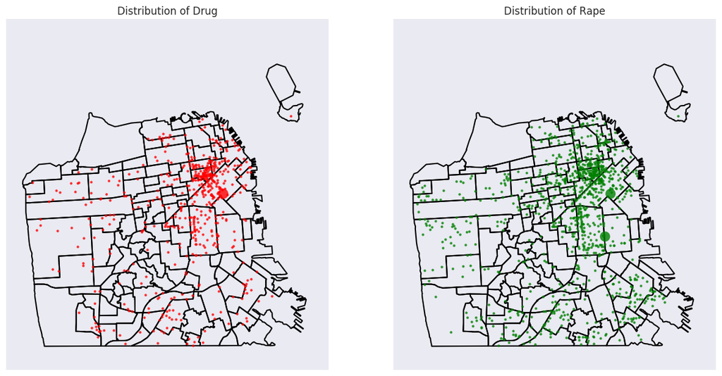

```python
# Use Basemap to draw map
fig = plt.figure()
fig.set_size_inches(15,30)
ax = fig.add_subplot(121)
ax.set_title("Distribution of Drug")

my_map = Basemap(llcrnrlon=-122.524120, llcrnrlat=37.697668, urcrnrlon= -122.344332, urcrnrlat=37.852423,
                 resolution="f", projection="merc"
)

plt.rcParams['figure.figsize'] = (12, 12)
my_map.readshapefile("SF Find Neighborhoods/geo_export_c3dd82f5-c220-4242-9541-7c95ca203a9f",
                     "areas", zorder=2, linewidth=1.5)

for lon, lat, count in zip(drug.Lon, drug.Lat, drug.CaseNum):
        x, y = my_map(lon, lat)
        color = 'r'
        marker = 'o'
        my_map.plot(x, y, color + marker, markersize = (count/8)**2+3, alpha=0.8)

ax = fig.add_subplot(122)
ax.set_title("Distribution of Rape")
my_map = Basemap(llcrnrlon=-122.524120, llcrnrlat=37.697668, urcrnrlon= -122.344332, urcrnrlat=37.852423,
                 resolution="f", projection="merc"
)

plt.rcParams['figure.figsize'] = (12, 12)
my_map.readshapefile("SF Find Neighborhoods/geo_export_c3dd82f5-c220-4242-9541-7c95ca203a9f",
                     "areas", zorder=2, linewidth=1.5)
for lon, lat, count in zip(rape.Lon, rape.Lat, rape.CaseNum):
        x, y = my_map(lon, lat)
        color = 'g'
        marker = 'o'
        my_map.plot(x, y, color + marker, markersize = (count/40)**2+3, alpha=0.8)


my_map
```

# Problem 3

What are the best places to find food trucks?

```python
# Use geopandas to draw map
import geopandas as gpd
```

```python
zips = gpd.read_file("/Users/yizhou/Desktop/zip/cb_2015_us_zcta510_500k.shp")
```

```python
sql_command = """
SELECT L.locationid, COUNT(permit) AS Count, Latitude, Longitude
FROM mobile_food_schedule AS L
LEFT JOIN mobile_food_locations AS R
ON L.locationid = R.locationid
GROUP BY L.locationid
ORDER BY COUNT(permit) DESC
"""
count_df = pd.read_sql(sql_command, db)
count_df.head()
```

|  | locationid | Count | Latitude | Longitude |
| --- | --- | --- | --- | --- |
| 0 | 934562 | 20 | 37.763807 | -122.412611 |
| 1 | 559774 | 15 | 37.782424 | -122.393236 |
| 2 | 559776 | 15 | 0.000000 | 0.000000 |
| 3 | 559777 | 15 | 37.788457 | -122.399884 |
| 4 | 559778 | 15 | 37.768307 | -122.412000 |

```python
count_df = count_df[((count_df.Latitude==0)|(count_df.Longitude==0))==False]
count_df.head()
```

|  | locationid | Count | Latitude | Longitude |
| --- | --- | --- | --- | --- |
| 0 | 934562 | 20 | 37.763807 | -122.412611 |
| 1 | 559774 | 15 | 37.782424 | -122.393236 |
| 3 | 559777 | 15 | 37.788457 | -122.399884 |
| 4 | 559778 | 15 | 37.768307 | -122.412000 |
| 5 | 559779 | 15 | 37.795106 | -122.400877 |

```python
lonlat = [geom.Point(lon, lat) for lon, lat in zip(count_df.Longitude, count_df.Latitude)]
count_df.drop(["Longitude", "Latitude"], axis = 1)

count_df = gpd.GeoDataFrame(count_df, geometry = lonlat, crs = {'init' :'epsg:4326'})
count_df.geometry.head()
```

```
0     POINT (-122.412610953897 37.7638066535277)
1     POINT (-122.393236399398 37.7824235632947)
3    POINT (-122.399884160566 37.78845702882889)
4        POINT (-122.412000336092 37.7683069928)
5     POINT (-122.400876633726 37.7951055609814)
Name: geometry, dtype: object
```

```python
biggest = count_df[count_df['Count'] > 15]
big = count_df[(count_df.Count < 20) & (count_df.Count >= 15)]
medium = count_df[(count_df.Count < 15) & (count_df.Count >= 10)]
small = count_df[count_df['Count'] < 10]
```

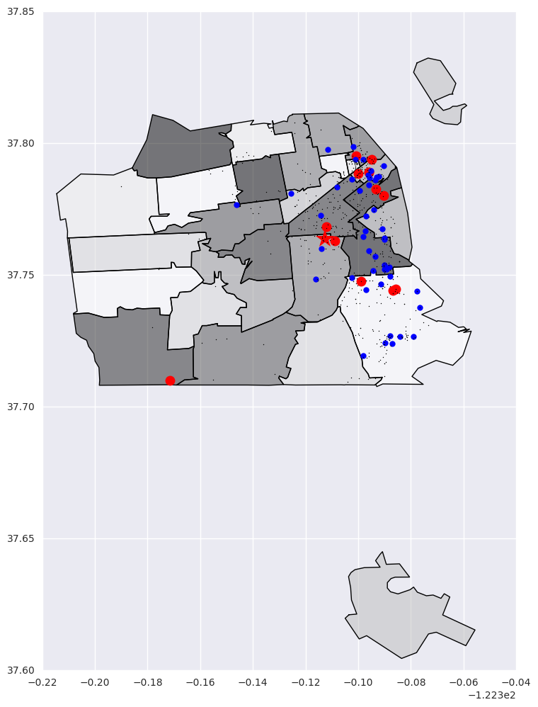

```python
# According to Wikipedia, CA zips are between 94102 and 94188
zips = zips[zips.ZCTA5CE10.str.startswith("941")]
zips = zips[pd.to_numeric(zips.ZCTA5CE10) <= 94188]
zips = zips[pd.to_numeric(zips.ZCTA5CE10) >= 94102]
base = zips.plot()

base1 = biggest.plot(ax= base, marker = '*', color = "red",markersize = 20)
base2 = big.plot(ax= base1, marker = 'o', color = "red",markersize = 10)
base3 = medium.plot(ax= base2, marker = 'o', color = "blue",markersize = 6)
small.plot(ax=base3, marker = 'o', color = "black",markersize = 1)
```

This part, I am looking for the best place to find food trucks. I join the mobile_food_schedule table and mobile_food_location table. I count each applicant/permit by local ID, and plot these pots in the map, so that I can tell which location has the most food truck by looking through the map. I divided my table into 4 different parts: the location which has most food truck is marked as a red big star; the locations which have considerable many food trucks are marked as red big dots; the locations which have moderate food trucks are marked as blue dots and the locations which have little food trucks are marked as black small dots. If we look at the map, the red star region is near Mission District. This (37.763807, -122.412611) location has almost 20 food truck. This make sense because this location has some theatres and a market nearby, so many people may go there buy food. There are also lots of red dots and blues dots around financial street area. This also make sense, because there is the center of the city, and many big financial cooperates are also located there. Some visitors and employers may need to buy food there.

# Question 4

What are the best time to find food truck?

```python
db.row_factory = sql.Row
cursor = db.execute("SELECT * FROM sqlite_master")
rows = cursor.fetchall()
schedule = pd.read_sql("SELECT * FROM mobile_food_schedule", db)
weekday = schedule[(schedule.DayOfWeek == 'Mo') | (schedule.DayOfWeek == 'Tu') | (schedule.DayOfWeek == 'We') | (schedule.DayOfWeek == 'Th') | (schedule.DayOfWeek == 'Fr')]
weekend = schedule[(schedule.DayOfWeek == 'Sa') | (schedule.DayOfWeek == 'Su')]
```

```python
time_list1 = []
for i,j in zip(weekday.StartHour,weekday.EndHour):
    time_list1.append(range(i,j+1))
```

```python
time_list2 = []
for i,j in zip(weekend.StartHour,weekend.EndHour):
    time_list2.append(range(i,j+1))
```

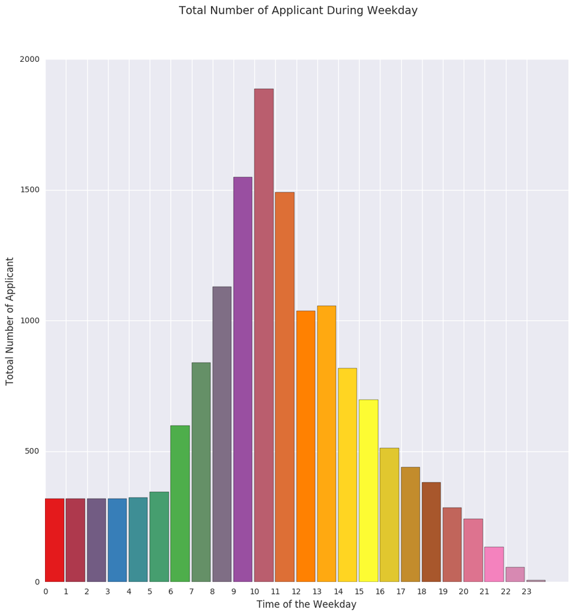

```python
data = pd.DataFrame(list(chain(*time_list1)))

years = collections.Counter(data[0]).keys()
people = collections.Counter(data[0]).values()
time = np.arange(len(people))
bar_width = 0.9
cs=cm.Set1(np.arange(len(time))/float(len(time)))
plt.bar(time, people, bar_width,  color=cs)

plt.suptitle('Total Number of Applicant During Weekday', fontsize=14)
plt.ylabel('Totoal Number of Applicant', fontsize=12)
plt.xlabel('Time of the Weekday', fontsize=12)

plt.xticks(time , years)
plt.show()
```

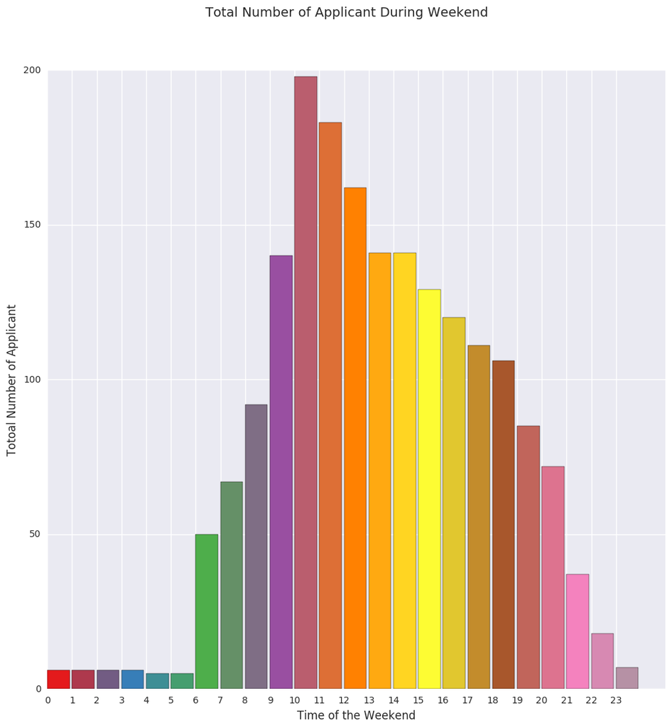

```python
data = pd.DataFrame(list(chain(*time_list2)))

years = collections.Counter(data[0]).keys()
people = collections.Counter(data[0]).values()
time = np.arange(len(people))
bar_width = 0.9
cs=cm.Set1(np.arange(len(time))/float(len(time)))
plt.bar(time, people, bar_width,  color=cs)

plt.suptitle('Total Number of Applicant During Weekend', fontsize=14)
plt.ylabel('Totoal Number of Applicant', fontsize=12)
plt.xlabel('Time of the Weekend', fontsize=12)

plt.xticks(time , years)
plt.show()
```

In this part, I am trying find the best time for finding food truck. I look at the mobile_food_schedule table, and divide the table into two parts: weekdays and weekends. I count the total number of applicants/permits for every 24 hours. The first bar plot shows the distribution of time schedule of food truck in weekdays. We can see that 9 a.m. to 12 p.m have the most food trucks. This make sense, since lots of employers start work at 9, and have lunch break around 12. These food trucks can provide employers with breakfast and lunch. The second bar plot shows the distribution of time schedule of food truck during weekend. Different from the weekday plot, the distribution of food truck skewed to the right. 10 a.m to 1 p.m. have the most food truck, and even in the afternoon, from 1 p.m. to 8p.m., there are still moderate many food trucks. Because this is during the weekends, most of people tend to wake up late and sleep late. So there will be more food truck in the afternoon during the weekend compared with the weekday.

# Question 5

Which type of park has the most acreage in sf? What is the most usual parks in the SF?

```python
parks = df = pd.read_sql(
    "SELECT Type, COUNT(*) AS count, AVG(Acreage) AS mean,SUM(Acreage) AS sum FROM parks GROUP BY Type",db)
```

```python
parks
```

|  | Type | count | mean | sum |
| --- | --- | --- | --- | --- |
| 0 | Civic Plaza or Square | 10 | 4.373000 | 43.73 |
| 1 | Community Garden | 18 | 0.316111 | 5.69 |
| 2 | Concession | 2 | 43.620000 | 87.24 |
| 3 | Family Camp | 1 | 337.510000 | 337.51 |
| 4 | Mini Park | 45 | 0.276000 | 12.42 |
| 5 | Neighborhood Park or Playground | 131 | 4.422748 | 579.38 |
| 6 | Parkway | 2 | 20.740000 | 41.48 |
| 7 | Regional Park | 19 | 155.626842 | 2956.91 |
| 8 | Zoological Garden | 1 | 131.520000 | 131.52 |

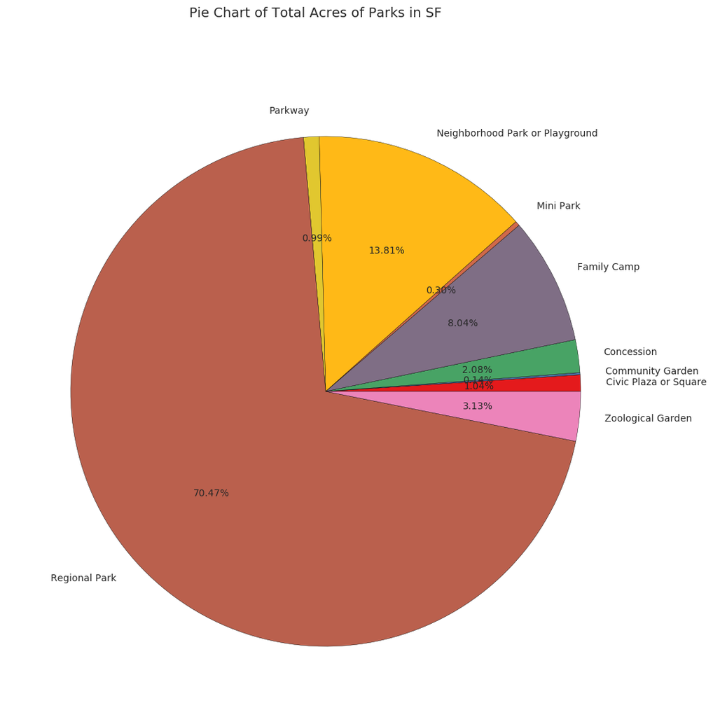

```python
# Draw pie chart
b = parks[['Type','sum']]
b = b.sort_values('sum',axis = 0, ascending = False)
cs=cm.Set1(np.arange(len(b))/float(len(b)))
plt.pie(parks['sum'],labels=parks['Type'],shadow=False, colors=cs,autopct='%.2f%%')
plt.suptitle('Pie Chart of Total Acres of Parks in SF', fontsize=14)
plt.show()
```

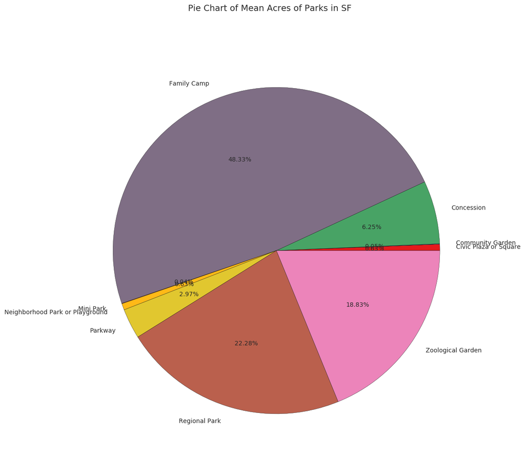

```python
b = parks[['Type','mean']]
b = b.sort_values('mean',axis = 0, ascending = False)
cs=cm.Set1(np.arange(len(b))/float(len(b)))
plt.pie(parks['mean'],labels=parks['Type'],shadow=False, colors=cs,autopct='%.2f%%')
plt.suptitle('Pie Chart of Mean Acres of Parks in SF', fontsize=14)
plt.show()
```

In this part, I am going to look at the park table，and want to know which kind of park appear the most in SF city, and which type of park has the most acerage. I have draw two pie charts: The first pie charts are the total acres of different type of parks in SF. we can see that regional park almost take the 71% of the total acerage. Because a regional park is an area of land preserved on account of its natural beauty, historic interest, recreational use or other reason, and under the administration of a form of local government, it make sense SF has lots of the acreage of regional parks.The Neighborhood Park or Playground also takes about 14% of the total acerage because it has total 131 locations in SF. Since SF is a very big city, it should has lots of communities and apartments, so it is reasonable to have many Neighborhood Park or Playground. Neighborhood Park or Playground is the most usual park type in sf.

The second pie charts are the mean of acreage of different type of parks in SF. We can see that Family Camp takes about half of the total acerages, and SF only has this big Family Camp. Besides Family Camp, Regional Park and Zoological Garden also has big percentage of the total acres.